# Part II - (Variables that investigate Combined Fuel efficiency)

## Investigation Overview

> In this investigation I wanted to look at the fuel efficiency of vehicles against various variables such as year(To get a view of how fuel efficiency has improved over a certain time period), engine size (To see whether the size of the engine affects the fuel efficiency of the vehicle) and Vehicle Class( To know which class of vehicles are much more fuel efficient)

## Dataset Overview

> The dataset consists of 3929 entries and 20 columns. Variables such as engine size, year and Vehicle Class are compared against combined fuel efficiency to look at fuel efficiency in the periods between 2013 to 2018.

```python
# import all packages and set plots to be embedded inline
import numpy as np
import pandas as pd
import matplotlib.pyplot as plt
import seaborn as sns

%matplotlib inline

# suppress warnings from final output
import warnings
warnings.simplefilter("ignore")
```

```python
# load in the dataset into a pandas dataframe
df = pd.read_csv("fuel-econ.csv")
df_clean = df.copy()
```

## (Visualization 1)

> Fuel efficiency has a normal distribution. This implies that data near the mean occurs more frequently than that which is away from the mean. The distribution however has a few outliers suggesting that there are some data points which differ significantly from this observation.

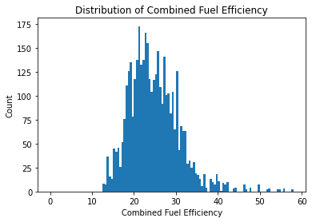

```python
bins = np.arange(0, df_clean['comb'].max()+0.5, 0.5)

# Plot the histogram for the height column
plt.hist(data=df_clean, x='comb', bins=bins)
plt.xlabel('Combined Fuel Efficiency')
plt.ylabel('Count');
plt.title('Distribution of Combined Fuel Efficiency')
plt.show();
```

## (Visualization 2)

> The dataset has various vehicle classes under investigation with Midsize cars and Compact cars being the majority of vehicls in the dataset, followed by Subcompact cars, Large cars and finally Minicompact cars which are the least in the dataset.

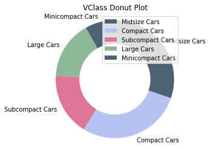

```python
colors = ['#4F6272', '#B7C3F3', '#DD7596', '#8EB897']
sorted_counts = df_clean['VClass'].value_counts()

plt.pie(sorted_counts, labels = sorted_counts.index, startangle = 90,
        counterclock = False, wedgeprops = {'width' : 0.4}, colors=colors);
plt.axis('square');
plt.title('VClass Donut Plot')
plt.legend();
```

## (Visualization 3)

> In the datatset under investigation, the majority of motorists use Premium Gasoline, followed by Regular Gasoline with Natural gas being the least used fuel type. Fuel type data is skewed to the right meaning that its mean data is greater than its median.

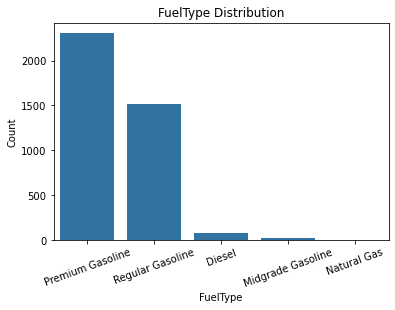

```python
base_color = sns.color_palette()[0]
sns.countplot(data=df_clean, x='fuelType', color=base_color);
plt.xticks(rotation=20)
plt.xlabel('FuelType')
plt.ylabel('Count');
plt.title('FuelType Distribution')
plt.show();
```

## (Visualization 4)

> The majority of vehicles in the dataset have a Front-Wheel transmision drive, followed by Rear wheel and all drive vehicles with the least being Automatic vehicles. The distribution is skewed to the right with Automatic drive being an outlier.

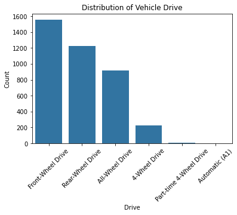

```python
base_color = sns.color_palette()[0]
sns.countplot(data=df_clean, x='drive', color=base_color, order = ['Front-Wheel Drive', 'Rear-Wheel Drive', 'All-Wheel Drive', '4-Wheel Drive','Part-time 4-Wheel Drive','Automatic (A1)']);
plt.xticks(rotation=45)
plt.xlabel('Drive')
plt.ylabel('Count');
plt.title('Distribution of Vehicle Drive')
plt.show();
```

## (Visualization 5)

> From the visualization, largest cars have the lowest fuel efficiencies, Compact and Midsize cars have the best efficiencies, and Mini and Subcompact cars have the next best efficiencies.

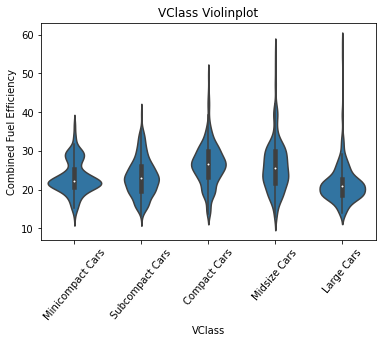

```python
base_color = sns.color_palette()[0]
sns.violinplot(data=df_clean, x='VClass', y='comb', color = base_color, order=['Minicompact Cars', 'Subcompact Cars', 'Compact Cars', 'Midsize Cars', 'Large Cars'])
plt.xticks(rotation = 50)
plt.xlabel('VClass')
plt.ylabel('Combined Fuel Efficiency');
plt.title('VClass Violinplot')
plt.show();
```

## (Visualization 6)

> Combined fuel efficiency has a negative correlation to co2 emissions. This implies that higher efficiency is met when co2 emissions are low,

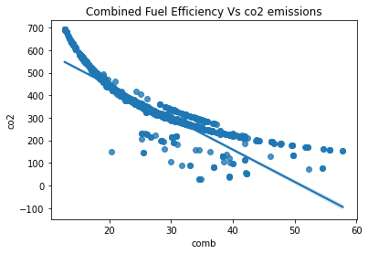

```python
sns.regplot(data = df_clean, x = 'comb', y = 'co2');
plt.xlabel('comb')
plt.ylabel('co2');
plt.title('Combined Fuel Efficiency Vs co2 emissions')
plt.show();
```

## (Visualization 7)

> Engine size and combined fuel efficiency are negatively correlated. This shows that a larger engines result to lower fuel efficiency and smaller engines are more fuel efficient.

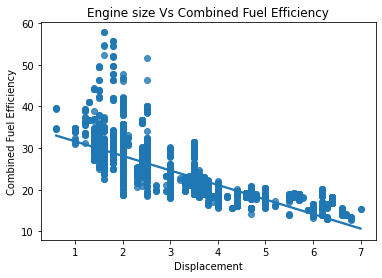

```python
sns.regplot(data = df_clean, x = 'displ', y = 'comb');
plt.xlabel('Displacement')
plt.ylabel('Combined Fuel Efficiency');
plt.title('Engine size Vs Combined Fuel Efficiency')
plt.show();
```

## (Visualization 8)

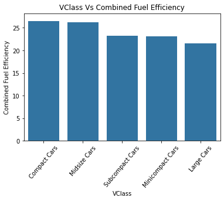

```python
sns.barplot(data=df_clean, x='VClass', y='comb', color=base_color, errwidth=0, order=['Compact Cars','Midsize Cars', 'Subcompact Cars','Minicompact Cars', 'Large Cars']);
plt.xticks(rotation = 50)
plt.xlabel('VClass')
plt.ylabel('Combined Fuel Efficiency');
plt.title('VClass Vs Combined Fuel Efficiency')
plt.show();
```

## (Visualization 9)

> Higher engine size equals higher levels of co2 emissions and less fuel efficient cars result to higher emissions.

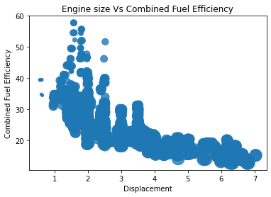

```python
sns.regplot(data = df_clean, x = 'displ', y= 'comb', x_jitter = 0.04, fit_reg = False, scatter_kws = {'s': df_clean['co2']/2});
plt.xlabel('Displacement')
plt.ylabel('Combined Fuel Efficiency');
plt.title('Engine size Vs Combined Fuel Efficiency')
plt.show();
```

## (Visualization 10)

> There is an upward trend in fuel efficiency over the years. This is has been made clear by the jitters with much darker areas showing overlapping of transparent points. This trend shows increased combined fuel efficiency by vehicle manufacturers over the yeras.

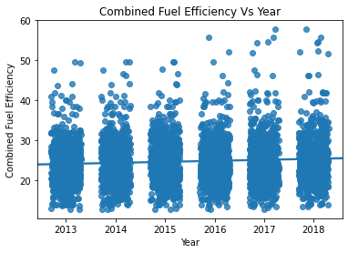

```python
sns.regplot(data = df_clean, x = 'year', y = 'comb', truncate=False, x_jitter=0.3)
plt.xlabel('Year')
plt.ylabel('Combined Fuel Efficiency')
plt.title('Combined Fuel Efficiency Vs Year')
plt.show();
```

## (Visualization 11)

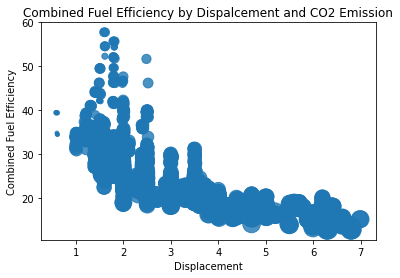

```python
sns.regplot(data = df_clean, x = 'displ', y= 'comb', x_jitter = 0.02, fit_reg = False, scatter_kws = {'s': df_clean['co2']/2});
plt.xlabel('Displacement')
plt.ylabel('Combined Fuel Efficiency')
plt.title('Combined Fuel Efficiency by Dispalcement and CO2 Emission')
plt.show();
```

## (Visualization 12)

> Subcompact, Compact and Midsize cars have more outliers. Vehicles with lower combined fuel efficiency have a much higher co2 emission rate in all vehicle classes.

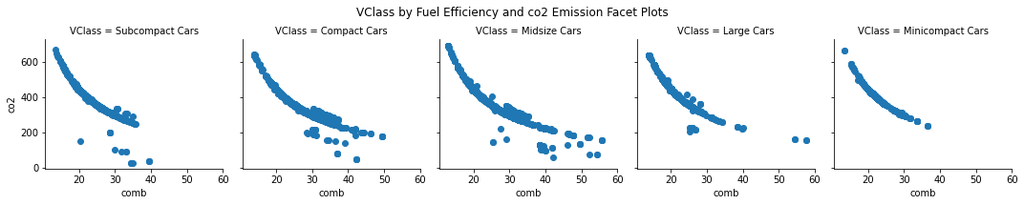

```python
g = sns.FacetGrid(data = df_clean, col = 'VClass')
g.map(plt.scatter, 'comb', 'co2')
plt.xlabel('comb')
plt.ylabel('co2')
  # Adding title to facet grid
g.fig.subplots_adjust(top= 0.82) #the 'top' parameter adjusts how high the title will be
g.fig.suptitle('VClass by Fuel Efficiency and co2 Emission Facet Plots')
plt.show();
```

## (Visualization 13)

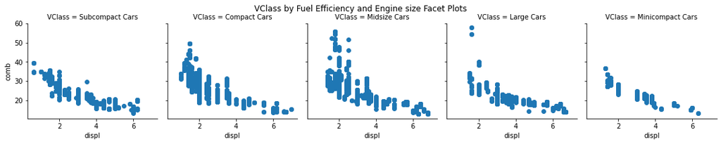

```python
g = sns.FacetGrid(data = df_clean, col = 'VClass')
g.map(plt.scatter, 'displ', 'comb')
plt.xlabel('displ')
plt.ylabel('comb')
  # Adding title to facet grid
g.fig.subplots_adjust(top= 0.85) #the 'top' parameter adjusts how high the title will be
g.fig.suptitle('VClass by Fuel Efficiency and Engine size Facet Plots')
plt.show();
```

### Generate Slideshow

Once you're ready to generate your slideshow, use the `jupyter nbconvert` command to generate the HTML slide show.